# R语言与机器学习（下）

### 参数选择

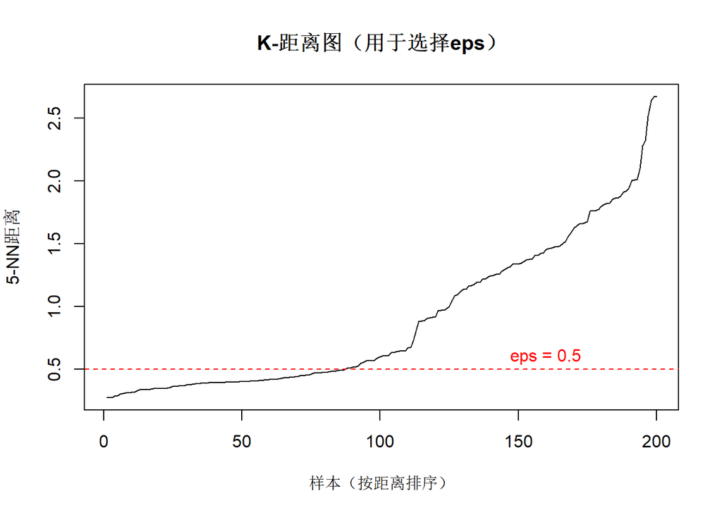

```r
# 使用k-距离图选择eps参数
# 计算每个点到其第k近邻的距离
k <- 5  # minPts - 1
knn_dist <- dbscan::kNNdist(dbscan_data[, c("x", "y")], k = k)

# kNNdist当k为单个值时返回向量，直接使用
# 绘制k-距离图（排序后）
knn_dist_sorted <- sort(knn_dist, decreasing = FALSE)

plot(knn_dist_sorted, type = "l",
     main = "K-距离图（用于选择eps）",
     xlab = "样本（按距离排序）", ylab = paste0(k, "-NN距离"))
abline(h = 0.5, col = "red", lty = 2)
text(length(knn_dist_sorted) * 0.8, 0.6, "eps = 0.5", col = "red")
```

### 意义与使用场景

**核心意义**：DBSCAN能够发现任意形状的簇，并自动识别噪声点，适合复杂数据结构。

**举例**：医学影像异常区域检测

**为什么这种数据适合用DBSCAN？**

医学影像中的病变区域往往形状不规则，且正常组织和异常组织的密度分布不同。DBSCAN可以基于像素特征的密度分布，发现任意形状的异常区域，同时识别噪声点（如伪影）。

**研究目的是什么？**

1. 发现影像中的异常区域
2. 自动识别噪声和伪影
3. 辅助医生定位病变

**可能得到什么样的结果？**

DBSCAN可能识别出多个密度较高的区域（疑似病变），同时标记出孤立的噪声点。医生可以重点检查这些区域。

**需要注意什么？**

参数eps和minPts的选择对结果影响很大。对于密度不均匀的数据，可能需要使用改进算法如HDBSCAN。

## 9.5 高斯混合模型（GMM）与EM算法

### 基本原理

**高斯混合模型（Gaussian Mixture Model, GMM）** 假设数据由多个高斯分布混合生成：

$$p(x) = \sum_{k=1}^{K} \pi_k
\mathcal{N}(x | \mu_k, \Sigma_k)$$

其中： - $\pi_k$：第k个高斯分量的混合系数（权重） - $\mu_k$：第k个高斯分量的均值 - $\Sigma_k$：第k个高斯分量的协方差矩阵

**EM算法**： 1. **E步**：计算每个样本属于各高斯分量的概率（后验概率） 2. **M步**：根据后验概率更新参数（均值、协方差、权重） 3. 重复直到收敛

```r
# GMM聚类示例
set.seed(42)

# 生成模拟数据：两个重叠的高斯分布
n_per_cluster <- 100

gmm_data <- data.frame(
  x = c(rnorm(n_per_cluster, mean = 0, sd = 1),
        rnorm(n_per_cluster, mean = 3, sd = 1.5)),
  y = c(rnorm(n_per_cluster, mean = 0, sd = 1),
        rnorm(n_per_cluster, mean = 2, sd = 1))
)

# 使用mclust包进行GMM聚类
gmm_result <- mclust::Mclust(gmm_data, G = 2)  # 指定2个分量

# 查看模型摘要
print(gmm_result)
```

```
## 'Mclust' model object: (EVI,2)
##
## Available components:
##  [1] "call"           "data"           "modelName"      "n"
##  [5] "d"              "G"              "BIC"            "loglik"
##  [9] "df"             "bic"            "icl"            "hypvol"
## [13] "parameters"     "z"              "classification" "uncertainty"
```

### 可视化GMM结果

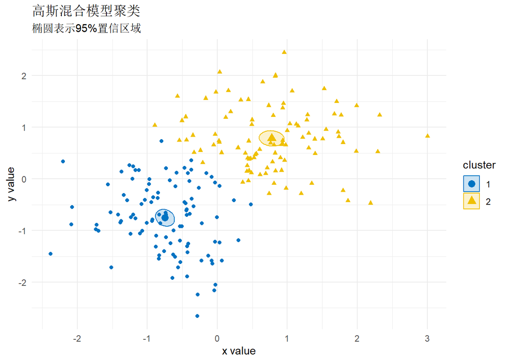

```r
# 使用factoextra包可视化
factoextra::fviz_cluster(gmm_result, data = gmm_data,
                         ellipse.type = "confidence",
                         ellipse.level = 0.95,
                         geom = "point",
                         palette = "jco") +
  ggplot2::labs(
    title = "高斯混合模型聚类",
    subtitle = "椭圆表示95%置信区域"
  ) +
  ggplot2::theme_minimal()
```

### 软聚类 vs 硬聚类

```r
# GMM提供软聚类（概率分配）
# 查看每个样本属于各簇的概率
prob_df <- as.data.frame(gmm_result$z)
colnames(prob_df) <- c("P(簇1)", "P(簇2)")
prob_df$sample <- 1:nrow(prob_df)
prob_df$assigned_cluster <- gmm_result$classification

# 查看前10个样本的概率分配
head(prob_df, 10)
```

```
##       P(簇1)       P(簇2) sample assigned_cluster
## 1  0.9999325 6.753952e-05      1                1
## 2  0.9944366 5.563433e-03      2                1
## 3  0.8401161 1.598839e-01      3                1
## 4  0.3338216 6.661784e-01      4                2
## 5  0.9998823 1.177108e-04      5                1
## 6  0.9998853 1.146762e-04      6                1
## 7  0.9918100 8.190009e-03      7                1
## 8  0.9998381 1.619277e-04      8                1
## 9  0.9728473 2.715268e-02      9                1
## 10 0.9973525 2.647517e-03     10                1
```

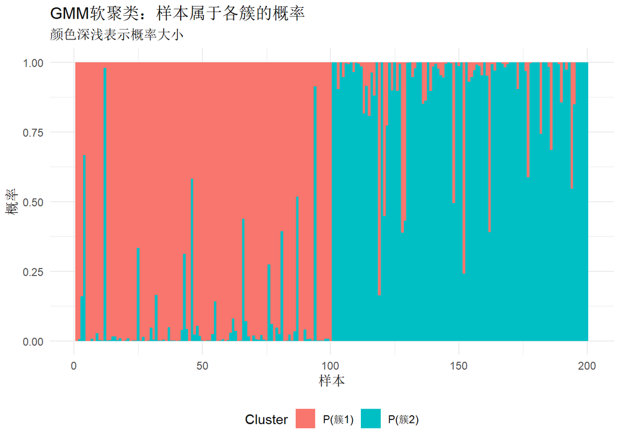

```r
# 可视化概率分布
prob_df_melt <- tidyr::pivot_longer(prob_df,
                                     cols = c("P(簇1)", "P(簇2)"),
                                     names_to = "Cluster",
                                     values_to = "Probability")

ggplot2::ggplot(prob_df_melt, ggplot2::aes(x = sample, y = Probability, fill = Cluster)) +
  ggplot2::geom_bar(stat = "identity", position = "stack", width = 1) +
  ggplot2::labs(
    title = "GMM软聚类：样本属于各簇的概率",
    subtitle = "颜色深浅表示概率大小",
    x = "样本", y = "概率"
  ) +
  ggplot2::theme_minimal() +
  ggplot2::theme(legend.position = "bottom")
```

### 意义与使用场景

**核心意义**：GMM提供概率性的聚类结果，适合需要不确定性估计的场景。

**举例**：疾病风险分层

**为什么这种数据适合用GMM？**

疾病风险往往是连续的，患者可能同时具有多种风险特征。GMM的软聚类可以给出患者属于各风险组的概率，更符合医学实际。

**研究目的是什么？**

1. 风险分层：将患者分配到不同风险组
2. 不确定性估计：提供概率而非硬标签
3. 识别过渡状态：发现介于各风险组之间的患者

**可能得到什么样的结果？**

GMM可能发现患者以80%概率属于高风险组，20%概率属于中风险组，而非简单的”高风险”标签。

**需要注意什么？**

GMM假设数据服从高斯分布，对于非高斯数据效果可能不好。需要指定分量数量，可以使用BIC等准则自动选择。